# Mini-Review: An Applied Example

Lecture 6A

PUBHBIO 6250

## Example: Pregnancy and COVID Symptoms

- **Goal**: Examine the association between pregnancy and COVID-19 symptoms in a Middle Eastern population.

  *[Al-Qassem AK, Humaidi AB, Al-Kuwari AK, Hasan EM, Yakti NH, et al. (2023) Association between pregnancy and severe COVID-19 symptoms in Qatar: A cross-sectional study. PLOS Global Public Health 3(10): e0000891.](https://doi.org/10.1371/journal.pgph.0000891)*
- **Design**: Cross-sectional
- **Primary objective**: Compare COVID-19 symptomatic status between women with and without pregnancy
- **Study sample**: All women 18-49 years of age with confirmed COVID-19 in Qatar from April-September 2020

## Study Recruitment Flowchart

*[Figure 1 in Al-Qassem et al. (2023)](https://doi.org/10.1371/journal.pgph.0000891)*

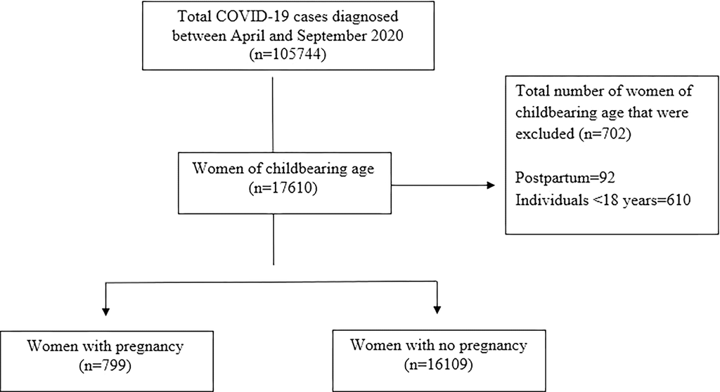

- Technically a **census** of **all** confirmed COVID-19 cases in this time/location
- Do we need statistical inference here (e.g., statistical tests)?
- What “population” is this a sample from?

## Summary of Study Sample

| Characteristic |  | Not Pregnant | Pregnant |
| --- | --- | --- | --- |
| N |  | 16,108 | 799 |
| Age, Mean (SD) |  | 33.1 (7.76) | 29.9 (5.16) |
| Region of origin | Asia | 7,815 (48.5%) | 290 (36.3%) |
| Region of origin | Middle East/North Africa | 7,269 (45.1%) | 477 (59.7%) |
| Region of origin | Sub-Saharan Africa | 745 (4.6%) | 22 (2.8%) |
| Region of origin | Other | 279 (1.7%) | 10 (1.3%) |
| Reports any symptoms |  | 10,912 (67.7%) | 591 (74.0%) |
| Number of symptoms | Median (IQR) | 2 (0, 3) | 2 (0, 3) |
|  | Mean (SD) | 1.99 (1.97) | 2.16 (1.96) |

- Pregnant women are younger, more likely to be of MENA origin, appear to (maybe) report more symptoms

## Model

- **Outcome:** $Y$ = reported any symptoms of COVID-19 (**binary**)
- **Predictors:**

  Pregnancy status (binary) = $PREG$ = $\begin{cases} 1 & \text{pregnant} \\ 0 & \text{not pregnant} \end{cases}$

  Age (continuous) = $AGE$

  Region of origin (4-level categorical) = $\begin{cases} R_{MENA} & \text{indicator for MENA (1/0)} \\ R_{AFR} & \text{indicator for African (1/0)} \\ R_{OTH} & \text{indicator for Other (1/0)} \\ -- & \text{reference = Asian} \end{cases}$

**Logistic Regression Model:**

$$\text{logit}(P(Y=1|\textbf{x})) = \beta_0 + \beta_1 PREG + \beta_2 AGE + \beta_3 R_{MENA} + \beta_4 R_{AFR} + \beta_5 R_{OTH}$$

## Model: Interpretation

$\text{logit}(P(Y=1|\textbf{x})) = \beta_0 + \beta_1 PREG + \beta_2 AGE + \beta_3 R_{MENA} + \beta_4 R_{AFR} + \beta_5 R_{OTH}$

**Effect of Pregnancy Status** (binary)

- $e^{\beta_1}$ = odds ratio for pregnant $(PREG=1)$ vs non-pregnant $(PREG=0)$

**Effect of Age** (continuous)

- $e^{\beta_2}$ = odds ratio for a 1-year increase in age $(AGE)$

**Effect of Region of Origin** (categorical)

- $e^{\beta_3}$ = odds ratio for MENA $(R_{MENA})$ vs Asian (reference level)
- $e^{\beta_4}$ = odds ratio for African $(R_{AFR})$ vs Asian (reference level)
- $e^{\beta_5}$ = odds ratio for Other origins $(R_{OTH})$ vs Asian (reference level)

## Model: Estimates

$\text{logit}(P(Y=1|\textbf{x})) = \beta_0 + \beta_1 PREG + \beta_2 AGE + \beta_3 R_{MENA} + \beta_4 R_{AFR} + \beta_5 R_{OTH}$

|  |  | Coef. | SE | 95% CI | OR | SE | 95% CI | $p$-value |
| --- | --- | --- | --- | --- | --- | --- | --- | --- |
| **Intercept** |  | 0.383 | 0.079 | (0.229, 0.537) | 1.47 | 0.12 | (1.26, 1.71) | $<$ 0.001 |
| **Pregnant** |  | 0.248 | 0.083 | (0.085, 0.412) | 1.28 | 0.11 | (1.09, 1.51) | 0.003 |
| **Age** |  | 0.006 | 0.002 | (0.002, 0.010) | 1.01 | 0.002 | (1.002, 1.01) | 0.006 |
| **Origin** | MENA | 0.439 | 0.035 | (0.371, 0.508) | 1.55 | 0.05 | (1.45, 1.66) | $<$ 0.001 |
| **Origin** | African | -0.679 | 0.076 | (-0.828, -0.530) | 0.51 | 0.04 | (0.44, 0.59) | $<$ 0.001 |
| **Origin** | Other | 0.093 | 0.127 | (-0.156, 0.342) | 1.10 | 0.14 | (0.86, 1.41) | 0.466 |

## Model: Estimates

$\text{logit}(P(Y=1|\textbf{x})) = \beta_0 + \beta_1 PREG + \beta_2 AGE + \beta_3 R_{MENA} + \beta_4 R_{AFR} + \beta_5 R_{OTH}$

|  | Coef. | SE | 95% CI | OR | SE | 95% CI | $p$-value |
| --- | --- | --- | --- | --- | --- | --- | --- |
| **Pregnant** | 0.248 | 0.083 | (0.085, 0.412) | 1.28 | 0.11 | (1.09, 1.51) | 0.003 |

**Pregnancy status effect:** OR = $e^{\hat{\beta}_1} = e^{0.248} = 1.28$

**Interpretation**: The odds of any COVID-19 symptoms for pregnant women are 1.28 times the odds for non-pregnant women, holding constant age and region of origin.

**Conclusion about “significance”?**

$p$-value = 0.003 $<$ 0.05, 0 is not in the 95% CI of $\hat{\beta}_1$, and 1 is not in the 95% CI of $\exp(\hat{\beta}_1)$ $\rightarrow$ **statistically significant effect**

## Model: Estimates

$\text{logit}(P(Y=1|\textbf{x})) = \beta_0 + \beta_1 PREG + \beta_2 AGE + \beta_3 R_{MENA} + \beta_4 R_{AFR} + \beta_5 R_{OTH}$

|  | Coef. | SE | 95% CI | OR | SE | 95% CI | $p$-value |
| --- | --- | --- | --- | --- | --- | --- | --- |
| **Age** | 0.006 | 0.002 | (0.002, 0.010) | 1.01 | 0.002 | (1.002, 1.01) | 0.006 |

**Age effect:** OR = $e^{\hat{\beta}_2} = e^{0.006} = 1.01$

**Interpretation**: The odds of reporting any COVID-19 symptoms increase by 1% for each 1-year increase in age.

**A 5-year increase in age**: The odds of reporting any COVID-19 symptoms increase by **3%** for **a 5-year increase in age**.

$\exp(\textcolor{#0000FF}{5} \times \hat{\beta}_2) = 1.03$

**Conclusion about “significance”?**: **statistically significant effect**

## Model: Estimates

$\text{logit}(P(Y=1|\textbf{x})) = \beta_0 + \beta_1 PREG + \beta_2 AGE + \beta_3 R_{MENA} + \beta_4 R_{AFR} + \beta_5 R_{OTH}$

|  | Coef. | SE | 95% CI | OR | SE | 95% CI | $p$-value |
| --- | --- | --- | --- | --- | --- | --- | --- |
| Origin: MENA | 0.439 | 0.035 | (0.371, 0.508) | 1.55 | 0.05 | (1.45, 1.66) | $<$ 0.001 |
| Origin: African | -0.679 | 0.076 | (-0.828, -0.530) | 0.51 | 0.04 | (0.44, 0.59) | $<$ 0.001 |
| Origin: Other | 0.093 | 0.127 | (-0.156, 0.342) | 1.10 | 0.14 | (0.86, 1.41) | 0.466 |

**Region of origin effect:** 3 ORs!

- OR for $R_{MENA}$ = $e^{\hat{\beta}_3} = e^{0.439} = 1.55$
- OR for $R_{AFR}$ = $e^{\hat{\beta}_4} = e^{-0.679} = 0.51$
- OR for $R_{OTH}$ = $e^{\hat{\beta}_5} = e^{0.093} = 1.10$

**Interpretations**: The odds of COVID-19 symptoms for women with an African origin are 0.51 times the odds of Asian women, holding constant pregnancy status and age. (49% lower odds)

## Model: Estimates

$\text{logit}(P(Y=1|\textbf{x})) = \beta_0 + \beta_1 PREG + \beta_2 AGE + \beta_3 R_{MENA} + \beta_4 R_{AFR} + \beta_5 R_{OTH}$

|  | Coef. | SE | 95% CI | OR | SE | 95% CI | $p$-value |
| --- | --- | --- | --- | --- | --- | --- | --- |
| Origin: MENA | 0.439 | 0.035 | (0.371, 0.508) | 1.55 | 0.05 | (1.45, 1.66) | $<$ 0.001 |
| Origin: African | -0.679 | 0.076 | (-0.828, -0.530) | 0.51 | 0.04 | (0.44, 0.59) | $<$ 0.001 |
| Origin: Other | 0.093 | 0.127 | (-0.156, 0.342) | 1.10 | 0.14 | (0.86, 1.41) | 0.466 |

**Region of origin effect:**

What about the OR for MENA vs African? MENA vs Other? African vs Other?

- To compare two non-reference levels, subtract the corresponding coefficients (and exponentiate to get the OR)
  - MENA vs African: $e^{(\hat{\beta}_3 - \hat{\beta}_4)} = e^{(.439 - -.679)} = 3.06$
  - MENA vs Other: $e^{(\hat{\beta}_3 - \hat{\beta}_5)} = e^{(.439 - .093)} = 1.41$
  - African vs Other: $e^{(\hat{\beta}_4 - \hat{\beta}_5)} = e^{(-.679 - .093)} = 0.46$

## Model: Estimates

$\text{logit}(P(Y=1|\textbf{x})) = \beta_0 + \beta_1 PREG + \beta_2 AGE + \beta_3 R_{MENA} + \beta_4 R_{AFR} + \beta_5 R_{OTH}$

|  | Coef. | SE | 95% CI | OR | SE | 95% CI | $p$-value |
| --- | --- | --- | --- | --- | --- | --- | --- |
| Origin: MENA | 0.439 | 0.035 | (0.371, 0.508) | 1.55 | 0.05 | (1.45, 1.66) | $<$ 0.001 |
| Origin: African | -0.679 | 0.076 | (-0.828, -0.530) | 0.51 | 0.04 | (0.44, 0.59) | $<$ 0.001 |
| Origin: Other | 0.093 | 0.127 | (-0.156, 0.342) | 1.10 | 0.14 | (0.86, 1.41) | 0.466 |

**Region of origin effect:** Conclusion about “significance”?

- Need to test $H_0: \beta_3 = \beta_4 = \beta_5 = 0$
- $\rightarrow$ Likelihood ratio test
  - test statistic = $299.61$
  - 3 DF (testing 3 $\beta$s) $\rightarrow$ under $H_0$, test stat $\sim \chi^2(3)$
  - $p$-value $<0.0001$

## Model: Testing Model Fit

$\text{logit}(P(Y=1|\textbf{x})) = \beta_0 + \beta_1 PREG + \beta_2 AGE + \beta_3 R_{MENA} + \beta_4 R_{AFR} + \beta_5 R_{OTH}$

- Want to test the fit of the model using Hosmer-Lemeshow test
  - $H_0:$ model fits

    $H_1:$ model does not fit
- For this model:
  - Number of groups: $K=10$ *(H-L test is based on grouping data via fitted probabilities)*
  - Test statistic: $\hat{C} = 20.54$
  - Under $H_0$, $\hat{C} \sim \chi^2(8)$
  - $p$-value = 0.0085 $\rightarrow$ Reject $H_0$
- Conclusion: model **does not fit well**
- Next steps: Try quadratic effect of $AGE$ (only continuous predictor)

## Revised Model: Estimates

$\text{logit}(P(Y=1|\textbf{x})) = \beta_0 + \beta_1 PREG + \textcolor{#008000}{\beta_2 AGE} + \textcolor{#008000}{\beta_6 AGE^2} + \beta_3 R_{MENA} + \beta_4 R_{AFR} + \beta_5 R_{OTH}$

|  |  | Coef. | SE | 95% CI | OR | SE | 95% CI | $p$-value |
| --- | --- | --- | --- | --- | --- | --- | --- | --- |
| Intercept |  | -0.410 | 0.285 | (-0.969, 0.149) | 0.66 | 0.19 | (0.38, 1.16) | 0.151 |
| Pregnant |  | 0.231 | 0.084 | (0.067, 0.395) | 1.26 | 0.11 | (1.07, 1.48) | 0.006 |
| Age |  | 0.056 | 0.017 | (0.022, 0.090) | 1.06 | 0.02 | (1.02, 1.09) | 0.001 |
| Age$^2$ |  | -.00074 | .00026 | (-.0012, -.00024) | .999 | .00026 | (.9988, .9998) | 0.004 |
| Origin | MENA | 0.455 | 0.035 | (0.385, 0.524) | 1.58 | 0.06 | (1.47, 1.69) | $<$ 0.001 |
| Origin | African | -0.689 | 0.076 | (-0.838, -0.539) | 0.50 | 0.04 | (0.43, 0.58) | $<$ 0.001 |
| Origin | Other | 0.102 | 0.127 | (-0.148, 0.351) | 1.11 | 0.14 | (0.86, 1.42) | 0.424 |

- Age$^2$ term $p$-value = 0.004; rerunning H-L test: $p$-value = 0.32 $\rightarrow$ Fail to Reject $H_0$
- Conclusion: model **fits**

## Revised Model: Interpretation

$\text{logit}(P(Y=1|\textbf{x})) = \beta_0 + \beta_1 PREG + \textcolor{#008000}{\beta_2 AGE} + \textcolor{#008000}{\beta_6 AGE^2} + \beta_3 R_{MENA} + \beta_4 R_{AFR} + \beta_5 R_{OTH}$

- Interpretations for pregnancy status and origin unchanged
  - Estimates changed a little but not much, “significance” conclusions unchanged
- But what about the effect of age? $AGE: \hat{\beta}_2 = 0.056$, $AGE^2: \hat{\beta}_6 =-.00074$
  - The effect of +1 year in age **depends on age**!
  - Challenging to interpret – one option is calculating OR at different $AGE$ values

    | Comparison | Estimated OR |
    | --- | --- |
    | Age 21 vs 20 | 1.026 |
    | Age 31 vs 30 | 1.011 |
    | Age 41 vs 40 | .996 |

  - The “effect of increasing age” is smaller for higher ages

    (positive sign on $AGE$ term but negative sign on $AGE^2$ term)

## Revised Model: Visualization

$\text{logit}(P(Y=1|\textbf{x})) = \beta_0 + \beta_1 PREG + \beta_2 AGE + \beta_6 AGE^2 + \beta_3 R_{MENA} + \beta_4 R_{AFR} + \beta_5 R_{OTH}$

- Plotting predicted probabilities can be helpful
- Plug in values for covariates to obtain predicted probabilities:

  $\hat{P}(\textbf{x}) = \frac{\exp\{\hat{\beta}_0 + \hat{\beta}_1 PREG + \hat{\beta}_2 AGE + \hat{\beta}_6 AGE^2 + \hat{\beta}_3 R_{MENA} + \hat{\beta}_4 R_{AFR} + \hat{\beta}_5 R_{OTH}\}}{1+ \exp\{\hat{\beta}_0 + \hat{\beta}_1 PREG + \hat{\beta}_2 AGE + \hat{\beta}_6 AGE^2 + \hat{\beta}_3 R_{MENA} + \hat{\beta}_4 R_{AFR} + \hat{\beta}_5 R_{OTH}\}}$

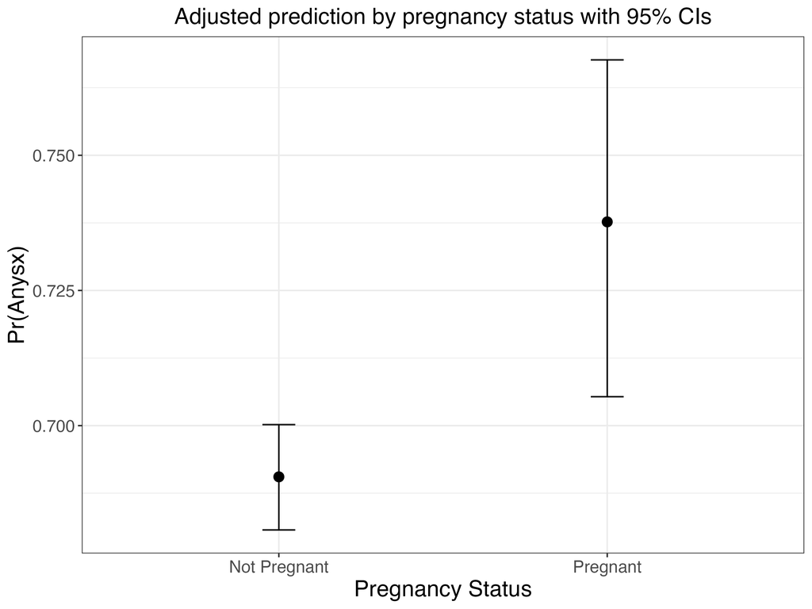

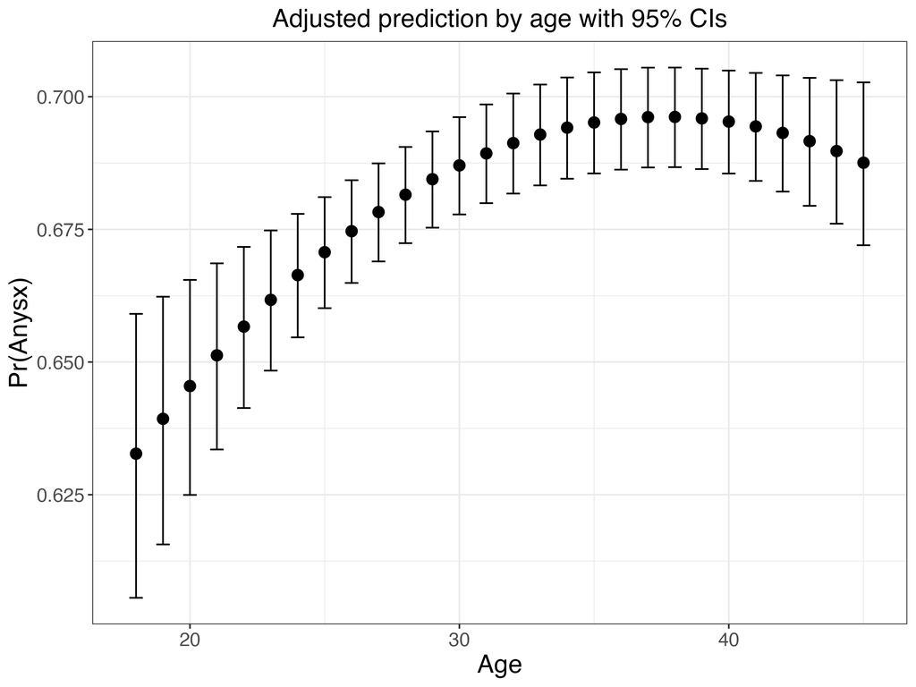

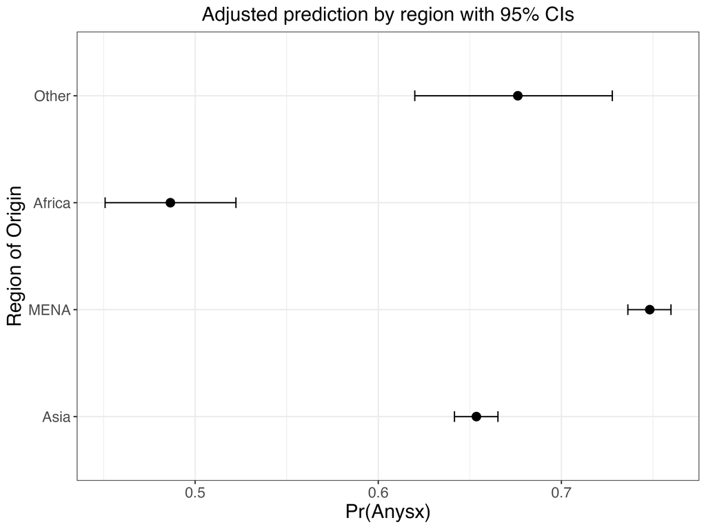

## Summary of Steps

To answer our research question, we…

- Thought about how data were collected and what population the sample represents
- Summarized the sample using appropriate summary statistics
- Identified our outcome ($Y$) variable and chose the type of regression model based on the type of variable $Y$ is
- Identified predictors of interest
- Figured out how to properly include the predictors in the model (e.g., set of indicator variables for categorical predictors)
- Fit the model and interpreted results
- Tested the fit of the model and made modifications when the model did not fit
- Interpreted the revised model (after testing its fit), including graphs to help visualize effects